- Programadores: Fatima T. y Anabel Baez
- Fecha: 2025-12-17

# Análisis de Datos "Cafe Madrid"

# Importacion de librerias

```python
import pandas as pd
import numpy as np
import matplotlib.pyplot as plt
import seaborn as sns
```

# Cargar el Dataset

```python
#Ejecucion dataset fátima

from google.colab import drive
drive.mount('/content/drive')

file_path = ('/content/drive/MyDrive/TFM/Outputs/Invoices19-25.csv')
try:
    df = pd.read_csv(file_path, low_memory=False)

    # 2. Conversión de date (Usamos dayfirst=True porque detectamos que el formato es europeo (dd/mm/yyyy))
    df['date'] = pd.to_datetime(df['date'], dayfirst=True, errors='coerce')
    print("✅ Carga correcta del dataset.")
except FileNotFoundError:
    print("❌ Error: No se encuentra el archivo. Verifica la ruta.")
```

```
✅ Carga correcta del dataset.
```

```python
# #Ejecucion dataset anabel

# file_path = ('1.Inputs/2025-12-10 Cafe Madrid Invoices 2019 to 2025 in table format.csv')
# try:
#     df = pd.read_csv(file_path, low_memory=False)

#     # 2. Conversión de date (Usamos dayfirst=True porque detectamos que el formato es europeo (dd/mm/yyyy))
#     df['date'] = pd.to_datetime(df['date'], dayfirst=True, errors='coerce')
#     print("✅ Carga correcta del dataset.")
# except FileNotFoundError:
#     print("❌ Error: No se encuentra el archivo. Verifica la ruta.")
```

# Estructura de los Datos

```python
# Configuración que permite mostrar todas las columnas
pd.set_option('display.max_columns', None)
pd.set_option('display.width', 1000)

# Visualizar las primeras filas del dataset omitiendo las filas que tienen más de un NaN
df.dropna(thresh=df.shape[1] - 1).head(5)

# Mostrar los 10 primeros registros
print("Los 10 primeros registros del DataFrame:")
display(df.head(10))
```

```
Los 10 primeros registros del DataFrame:
```

|  | invoice_number | invoice_type | related_invoice | date | location | grand_total | payment_method | amount_paid | product | quantity | price | source_file |
| --- | --- | --- | --- | --- | --- | --- | --- | --- | --- | --- | --- | --- |
| 0 | F-16 | F | NaN | 2019-04-08 | Barra/B1 | 110.55 | Tarjeta | 110.55 | MASCARPONE Y FRUTOS | 1.0 | 3.95 | 2019_1S_Invoice_layout_CafeMadrid.JSON |
| 1 | F-16 | F | NaN | 2019-04-08 | Barra/B1 | 110.55 | Tarjeta | 110.55 | CAFE CON LECHE | 3.0 | 5.40 | 2019_1S_Invoice_layout_CafeMadrid.JSON |
| 2 | F-16 | F | NaN | 2019-04-08 | Barra/B1 | 110.55 | Tarjeta | 110.55 | TARTA DE CALABAZA | 1.0 | 3.95 | 2019_1S_Invoice_layout_CafeMadrid.JSON |
| 3 | F-16 | F | NaN | 2019-04-08 | Barra/B1 | 110.55 | Tarjeta | 110.55 | * Leche de Avena | 1.0 | 0.30 | 2019_1S_Invoice_layout_CafeMadrid.JSON |
| 4 | F-16 | F | NaN | 2019-04-08 | Barra/B1 | 110.55 | Tarjeta | 110.55 | AGUA MINERAL BOTELL | 1.0 | 1.80 | 2019_1S_Invoice_layout_CafeMadrid.JSON |
| 5 | F-16 | F | NaN | 2019-04-08 | Barra/B1 | 110.55 | Tarjeta | 110.55 | TE GREEN TE | 1.0 | 2.30 | 2019_1S_Invoice_layout_CafeMadrid.JSON |
| 6 | F-16 | F | NaN | 2019-04-08 | Barra/B1 | 110.55 | Tarjeta | 110.55 | COOKIES | 3.0 | 5.40 | 2019_1S_Invoice_layout_CafeMadrid.JSON |
| 7 | F-16 | F | NaN | 2019-04-08 | Barra/B1 | 110.55 | Tarjeta | 110.55 | DONUTS CHOCOLATE | 2.0 | 3.60 | 2019_1S_Invoice_layout_CafeMadrid.JSON |
| 8 | F-16 | F | NaN | 2019-04-08 | Barra/B1 | 110.55 | Tarjeta | 110.55 | INF MANZANILLA | 2.0 | 4.60 | 2019_1S_Invoice_layout_CafeMadrid.JSON |
| 9 | F-16 | F | NaN | 2019-04-08 | Barra/B1 | 110.55 | Tarjeta | 110.55 | TE PU ERH | 2.0 | 4.60 | 2019_1S_Invoice_layout_CafeMadrid.JSON |

A la vista de los datos mostrados podemos comentar sobre las variables del dataset de ventas:

- **invoice_number**: Identificador único de la factura o ticket.
- **invoice_type**: Tipo de documento (Ticket de venta o Abono/Devolución).
- **related_invoice**: En caso de devolución, indica el identificador de la factura original a la que hace referencia.
- **date**: Fecha de la transacción.
- **location**: Ubicación donde se realizó la venta
- **grand_total**: Importe total de la factura en euros.
- **payment_method**: Método de pago utilizado (Efectivo, Tarjeta, etc.).
- **amount_paid**: Cantidad pagada realmente por el cliente.
- **product**: Nombre del producto vendido.
- **quantity**: Cantidad de unidades vendidas de dicho producto.
- **price**: Precio unitario del producto.
- **source_file**: Nombre del archivo de origen

Ahora procedemos a profundizar un poco más en el dataset viendo las dimensiones y alguna información adicional como los tipos de datos de cada columna.

```python
# Mostrar las columnas y tipos de datos
print("\nColumnas y tipos de datos del DataFrame:")
display(df.info())  # Información general de las columnas, tipos de datos y no nulos
```

```
Columnas y tipos de datos del DataFrame:
<class 'pandas.core.frame.DataFrame'>
RangeIndex: 957163 entries, 0 to 957162
Data columns (total 12 columns):
 #   Column           Non-Null Count   Dtype
---  ------           --------------   -----
 0   invoice_number   957163 non-null  object
 1   invoice_type     957163 non-null  object
 2   related_invoice  736 non-null     object
 3   date             957163 non-null  datetime64[ns]
 4   location         957163 non-null  object
 5   grand_total      957158 non-null  float64
 6   payment_method   955133 non-null  object
 7   amount_paid      955133 non-null  float64
 8   product          956332 non-null  object
 9   quantity         956332 non-null  float64
 10  price            956332 non-null  float64
 11  source_file      957163 non-null  object
dtypes: datetime64[ns](1), float64(4), object(7)
memory usage: 87.6+ MB
```

```
None
```

A la vista de los datos mostrados, tenemos un total de 12 variables y un volumen de 957.163 registros. Es un volumen manejable para poder hacer un análisis detallado. En cuanto a los tipos de datos, vemos que las variables están divididas en numéricas, categóricas y temporales:

Variables Numéricas (float64):

- grand_total
- amount_paid
- quantity
- price

Variables Categóricas (object):

- invoice_number
- invoice_type
- related_invoice
- location
- payment_method
- product
- source_file

Variable Temporal (datetime64):

- date

# Capítulo 1: Perfilamiento Inicial del Dataset (Exploratory Data Analysis - EDA)

# Analisis de variables numéricas

## 1.1. Análisis de Horizonte Temporal y Estadísticos Base En esta sección se exploran las métricas originales del dataset sin procesar para identificar anomalías y comportamientos base.

```python
# Describir el DataFrame

# Análisis de la variable 'date'
print("Rango Temporal del Dataset")
print(f"Fecha Inicio: {df['date'].min()}")
print(f"Fecha Fin:    {df['date'].max()}")
print(f"Total días:   {(df['date'].max() - df['date'].min()).days} días")

# Análisis de Variables Numéricas
cols_numericas = ['grand_total', 'amount_paid', 'quantity', 'price']
print("\n Estadísticos de Variables Numéricas")
display(df[cols_numericas].describe().T)
```

```
Rango Temporal del Dataset
Fecha Inicio: 2019-01-02 00:00:00
Fecha Fin:    2025-10-31 00:00:00
Total días:   2494 días

 Estadísticos de Variables Numéricas
```

|  | count | mean | std | min | 25% | 50% | 75% | max |
| --- | --- | --- | --- | --- | --- | --- | --- | --- |
| grand_total | 957158.0 | 11.254003 | 10.577232 | -704.30 | 4.75 | 8.5 | 14.6 | 907.55 |
| amount_paid | 955133.0 | 14.044851 | 13.713427 | 0.01 | 5.20 | 10.0 | 19.7 | 502.00 |
| quantity | 956332.0 | 1.187689 | 0.521097 | 0.00 | 1.00 | 1.0 | 1.0 | 53.00 |
| price | 956332.0 | 3.339044 | 2.645406 | 0.00 | 2.00 | 2.8 | 4.4 | 704.30 |

Tenemos un total de 4 variables numéricas a estudiar (grand_total, amount_paid, quantity y price). Todas ellas muestran cosas interesantes:

- **grand_total**: de los estadísticos podemos ver que casi todos los registros tienen valores (957.158). La media se sitúa aproximadamente en 11,25 € y una mediana de 8,50 € lo que sugiere una distribución asimétrica con muchos tickets de bajo importe, aunque, cabe mencionar que el valor máximo de 907,55 € es significativamente alto y podría indicar la presencia de valores atípicos (outliers) o eventos especiales. El valor mínimo de -704,30 € también es un claro candidato a devolución o abono contable que distorsiona la media.
- **quantity**: Observamos que su valor mínimo de 0 demuestra la existencia de outliers o errores de registro, puesto que no tiene sentido físico una venta de cero unidades. De manera similar, ocurre con su valor máximo de 53, que comparado con una media de 1,18, es un claro outlier.
- **price**: cuenta con casi todos sus valores alineados con la lógica de negocio, pero presenta un valor mínimo de 0. Este 0 podría ser un outlier, ya que un producto no suele tener coste cero. Su máximo de 704,30 € coincide en magnitud con los valores negativos del total, lo que sugiere consistencia en los datos extremos.
- **amount_paid**: muestra una media de 14,04 €, ligeramente superior al grand_total, lo cual es curioso y podría deberse a propinas o redondeos, aunque su mínimo de 0,01 € indica que no hay pagos nulos registrados.

Para ser un poco más ágiles en los cálculos, en este dataset no parece necesario quitar columnas numéricas de manera inmediata, ya que todas parecen potencialmente relevantes para el análisis de la facturación y el volumen de nulos es bajo. No obstante, las variables grand_total, quantity y price muestran claros outliers (negativos y ceros) que requerirán una fase de limpieza de datos específica para asegurar la calidad de nuestro análisis.

## 1.2 Visualización de Distribuciones Base

```
Variables numéricas:  ['grand_total' 'amount_paid' 'quantity' 'price']
```

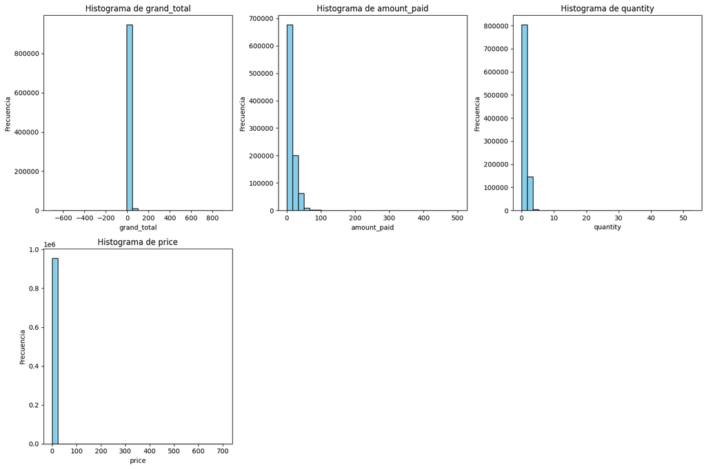

```python
# Identificar las columnas numéricas
numeric_columns = df.select_dtypes(include=[np.number]).columns
print("Variables numéricas: ", numeric_columns.values)

# Crear una figura con subplots
num_vars = len(numeric_columns)
fig, axes = plt.subplots(nrows=(num_vars // 3) + 1, ncols=3, figsize=(15, 5 * ((num_vars // 3) + 1)))
axes = axes.flatten()

for i, col in enumerate(numeric_columns):
    # Graficar el histograma
    axes[i].hist(df[col], bins=30, color='skyblue', edgecolor='black')
    axes[i].set_title(f'Histograma de {col}')
    axes[i].set_xlabel(col)
    axes[i].set_ylabel('Frecuencia')

# Eliminar ejes sobrantes si hay menos de 3 variables
for j in range(i + 1, len(axes)):
    fig.delaxes(axes[j])

plt.tight_layout()
plt.show()
```

A la vista de los histogramas iniciales, la conclusión es clara: estamos ante distribuciones fuertemente asimétricas.

grand_total: El histograma no tiene forma de campana (normal), sino que concentra una barra inmensa en la zona izquierda (precios bajos, entre 2€ y 15€) y una cola larguísima hacia la derecha que llega hasta los 900€.

quantity: Aquí el histograma es prácticamente una sola barra en el valor 1.Esto nos dice que el comportamiento de compra estándar es pedir un solo ítem por línea de ticket.

price: Sigue un patrón idéntico al total. La gran masa de datos está en precios unitarios muy bajos (probablemente cafés o bollería entre 1.5€ y 4€), con muy pocos productos de precio alto. Los outliers (tanto los tickets de 900€ como las devoluciones negativas) están distorsionando la escala de los gráficos, impidiendo ver cómo se distribuye realmente el consumo "normal" del día a día.

Para solucionar esto y entender mejor el comportamiento del cliente promedio, es necesario realizar un "zoom". Vamos a volver a generar los histogramas aplicando un filtro de percentil 95 (eliminando el 5% de los tickets más caros y las devoluciones), para ver con claridad la distribución central de las ventas.

## 1.3 Inspección Detallada de Distribuciones

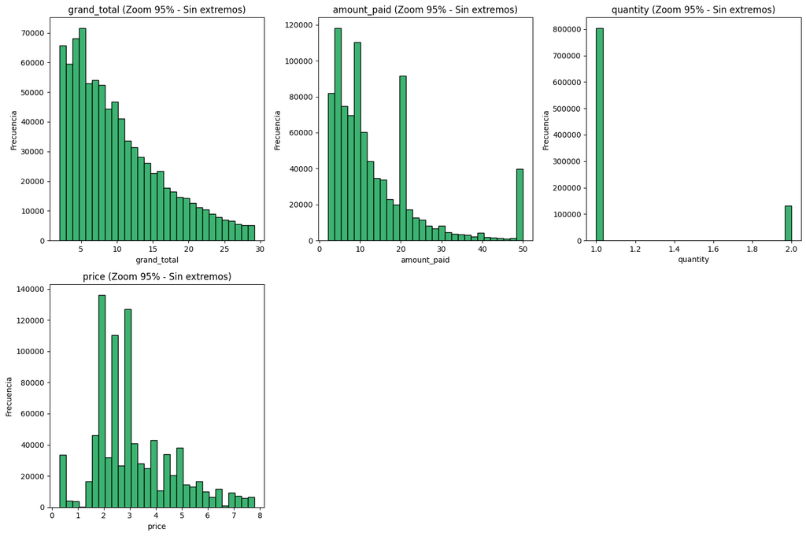

```python
# Histogramas con filtro de percentil al 95%

def plot_histograms(df, percentil=0.95):
    # Identificamos numéricas
    numeric_columns = df.select_dtypes(include=[np.number]).columns

    # Configuración de subplots
    num_vars = len(numeric_columns)
    fig, axes = plt.subplots(nrows=(num_vars // 3) + 1, ncols=3, figsize=(15, 5 * ((num_vars // 3) + 1)))
    axes = axes.flatten()

    for i, col in enumerate(numeric_columns):
        # Calculamos el corte (ej: el valor por debajo del cual está el 95% de los datos)
        limite_superior = df[col].quantile(percentil)
        limite_inferior = df[col].quantile(1 - percentil) # Opcional si hay negativos extremos

        # Filtramos solo para el gráfico (no borramos datos, solo los ocultamos en el plot)
        data_zoom = df[(df[col] <= limite_superior) & (df[col] >= limite_inferior)][col]

        # Graficamos los datos filtrados
        axes[i].hist(data_zoom, bins=30, color='mediumseagreen', edgecolor='black')
        axes[i].set_title(f'{col} (Zoom 95% - Sin extremos)')
        axes[i].set_xlabel(col)
        axes[i].set_ylabel('Frecuencia')

    # Eliminar ejes sobrantes
    for j in range(i + 1, len(axes)):
        fig.delaxes(axes[j])

    plt.tight_layout()
    plt.show()

# Llamamos a la función
plot_histograms(df, percentil=0.95)
```

Al aplicar el filtro del percentil 95 para omitir los valores extremos, los histogramas revelan por fin la verdadera naturaleza del negocio, que quedaba oculta por la larga cola de los outliers.

**1. Variables Monetarias** (grand_total y price): A diferencia del gráfico anterior, aquí observamos una distribución mucho más detallada. Vemos que el grueso de la facturación se concentra en un rango bajo (probablemente entre 2€ y 15€), lo cual confirma el modelo de negocio de una cafetería: alta rotación de tickets pequeños. Es muy probable que la distribución no sea una campana perfecta, sino que presente varios "picos" (multimodalidad). Esto suele corresponder a los precios estándar de los productos más vendidos: un pico en el precio del café, otro en el precio del desayuno completo y otro en el menú de mediodía.

**2. Variable de Cantidad** (quantity): El histograma ajustado corrobora nuestra hipótesis inicial de forma contundente. La barra correspondiente al valor 1 domina absolutamente el gráfico. Esto nos indica que el comportamiento de compra estándar del cliente es adquirir un único ítem por línea de pedido. Las cantidades de 2 o más unidades son residuales en comparación.

## 1.4 Calidad de Datos y Valores Faltantes

```python
# Tabla de porcentaje de registros con Missing Values por cada variable

# Calculamos suma y porcentaje
missing_data = df.isnull().sum()
missing_data_percentage = (missing_data / len(df)) * 100

# Creamos el DataFrame resumen
missing_summary = pd.DataFrame({
    'Missing Values': missing_data,
    'Percentage (%)': missing_data_percentage.round(2) # Redondeamos a 2 decimales
})

# Filtramos para mostrar solo las que tienen algún nulo (opcional, para limpiar la vista)
# y ordenamos de mayor a menor porcentaje
missing_summary = missing_summary[missing_summary['Missing Values'] > 0].sort_values(by='Percentage (%)', ascending=False)

print("\n--- Tabla de Porcentaje de Registros con Missing Values ---")
display(missing_summary)

print(f"\nTotal de filas en el dataset: {len(df)}")
```

```
--- Tabla de Porcentaje de Registros con Missing Values ---
```

|  | Missing Values | Percentage (%) |
| --- | --- | --- |
| related_invoice | 956427 | 99.92 |
| payment_method | 2030 | 0.21 |
| amount_paid | 2030 | 0.21 |
| quantity | 831 | 0.09 |
| product | 831 | 0.09 |
| price | 831 | 0.09 |
| grand_total | 5 | 0.00 |

```
Total de filas en el dataset: 957163
```

```python
# Cuenta de valores nulos por registro
null_counts = df.isnull().sum(axis=1)
summary = null_counts.value_counts().reset_index()
summary.columns = ['num_nulls', 'count']
summary = summary.sort_values('num_nulls').reset_index(drop=True)

# Aplicar estilo: Marcar en rojo solo si hay MÁS de 1 nulo (anomalía real)
def highlight_rows(s):
    color = 'background-color: red; color: white;' if s['num_nulls'] > 1 else ''
    return [color] * len(s)

summary_styled = summary.style.apply(highlight_rows, axis=1)

# Mostrar resultado
summary_styled
```

|  | num_nulls | count |
| --- | --- | --- |
| 0 | 1 | 955132 |
| 1 | 3 | 1197 |
| 2 | 4 | 4 |
| 3 | 5 | 736 |
| 4 | 6 | 92 |
| 5 | 7 | 2 |

## 1.5 Detección de Anomalías y Calidad de Datos

- Vamos a contabilizar los valores estrictamente 0 de estas variables. Para ello definimos una función que nos lo calcula:

```python
# Función para contar los ceros en cada columna numérica
def count_zeros(df):

    # Contar ceros en cada columna numérica
    zero_counts = df[numeric_columns].apply(lambda x: (x == 0).sum())

    return zero_counts

for i, col in enumerate(numeric_columns):
    # Llamar a la función para contar ceros
    zero_counts = count_zeros(df)
    print(f"Numero de 0s en {col}: {zero_counts[col]}")
```

```
Numero de 0s en grand_total: 501
Numero de 0s en amount_paid: 0
Numero de 0s en quantity: 8
Numero de 0s en price: 33732
```

El análisis de valores cero arroja los siguientes hechos sobre la integridad de los datos:

1. Inconsistencias en Cantidad (quantity = 8): Se detectan 8 registros con cantidad igual a 0. Estos 8 registros carecen de sentido lógico y constituyen un error de dato que debe depurarse.
2. Discrepancia entre Precio y Total (price vs grand_total):

Existen 33.732 líneas donde el precio unitario (price) es 0.Sin embargo, solo existen 501 facturas donde el total a pagar (grand_total) es 0.

Esto demuestra que el 98,5% de los productos con precio 0 aparecen dentro de facturas que sí tienen un coste monetario final mayor a cero. Es decir, son ítems de coste nulo incluidos en transacciones de pago.

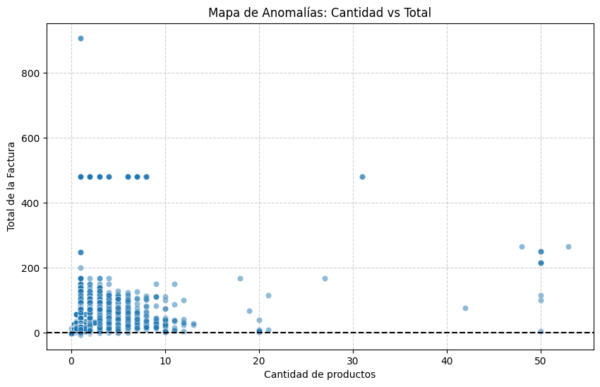

```python
plt.figure(figsize=(10, 6))

# Graficamos Cantidad vs Total
sns.scatterplot(data=df, x='quantity', y='grand_total', alpha=0.5)

plt.title('Mapa de Anomalías: Cantidad vs Total')
plt.axhline(0, color='black', linestyle='--') # Línea del cero
plt.xlabel('Cantidad de productos')
plt.ylabel('Total de la Factura')
plt.grid(True, linestyle='--', alpha=0.6)

plt.show()
```

## Análisis de Dispersión y Outliers

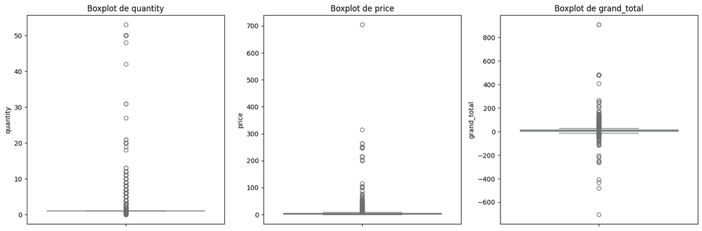

```
--- Detección de Outliers (Método IQR) ---

Variable: quantity
 - Rango Intercuartílico (IQR): 0.00
 - Límite inferior: 1.00
 - Límite superior: 1.00
 - Número de outliers detectados: 152694
 - Porcentaje de outliers: 15.95%
 - Valores extremos (min/max): 0.0 / 53.0

Variable: price
 - Rango Intercuartílico (IQR): 2.40
 - Límite inferior: -1.60
 - Límite superior: 8.00
 - Número de outliers detectados: 35032
 - Porcentaje de outliers: 3.66%
 - Valores extremos (min/max): 8.1 / 704.3

Variable: grand_total
 - Rango Intercuartílico (IQR): 9.85
 - Límite inferior: -10.02
 - Límite superior: 29.38
 - Número de outliers detectados: 47571
 - Porcentaje de outliers: 4.97%
 - Valores extremos (min/max): -704.3 / 907.55
```

```python
# Seleccionamos las variables numéricas de interés
target_cols = ['quantity', 'price', 'grand_total']

# Visualización mediante Diagramas de Caja (Boxplots)
plt.figure(figsize=(15, 5))
for i, col in enumerate(target_cols):
    plt.subplot(1, 3, i+1)
    sns.boxplot(y=df[col], color='skyblue')
    plt.title(f'Boxplot de {col}')
    plt.ylabel(col)
plt.tight_layout()
plt.show()

# Detección analítica de outliers usando el Rango Intercuartílico (IQR)
print("\n--- Detección de Outliers (Método IQR) ---")

for col in target_cols:
    Q1 = df[col].quantile(0.25)
    Q3 = df[col].quantile(0.75)
    IQR = Q3 - Q1

    # Definimos límites (usualmente 1.5 veces el IQR)
    lower_bound = Q1 - 1.5 * IQR
    upper_bound = Q3 + 1.5 * IQR

    # Identificamos los outliers
    outliers = df[(df[col] < lower_bound) | (df[col] > upper_bound)]

    print(f"\nVariable: {col}")
    print(f" - Rango Intercuartílico (IQR): {IQR:.2f}")
    print(f" - Límite inferior: {lower_bound:.2f}")
    print(f" - Límite superior: {upper_bound:.2f}")
    print(f" - Número de outliers detectados: {len(outliers)}")
    print(f" - Porcentaje de outliers: {(len(outliers) / len(df)) * 100:.2f}%")

    if len(outliers) > 0:
        print(f" - Valores extremos (min/max): {outliers[col].min()} / {outliers[col].max()}")
```

## 1.6 Análisis de Variables Categóricas - Cardinalidad

- Ahora vamos a pasar a estudiar las variables categóricas. Empezaremos analizando la cardinalidad de dichas variables, es decir, vamos a ver cuantas categorías tiene cada variable categórica

```python
# Identificamos columnas categóricas
cat_cols = df.select_dtypes(include=['object']).columns

# Calculamos la cardinalidad (número de valores únicos)
cardinality = df[cat_cols].nunique().sort_values(ascending=False)

print("\n Cardinalidad de Variables Categóricas")
print(cardinality)

# Filtramos las variables con baja cardinalidad
umbral = 50
low_cardinality_cols = cardinality[cardinality < umbral].index.tolist()
high_cardinality_cols = cardinality[cardinality >= umbral].index.tolist()

print(f"\n Variables de Baja Cardinalidad (< {umbral})")
print(f" {low_cardinality_cols}")

print(f"\n Variables de Alta Cardinalidad (>= {umbral})")
display(f" {high_cardinality_cols}")
```

```
 Cardinalidad de Variables Categóricas
invoice_number     401032
related_invoice       722
product               499
location               36
source_file            17
invoice_type            3
payment_method          2
dtype: int64

 Variables de Baja Cardinalidad (< 50)
 ['location', 'source_file', 'invoice_type', 'payment_method']

 Variables de Alta Cardinalidad (>= 50)
```

```
" ['invoice_number', 'related_invoice', 'product']"
```

El estudio de la cardinalidad nos permite clasificar las variables categóricas en dos grupos diferenciados según su tratabilidad:

Las variables payment_method, invoice_type y location son candidatas directas para el análisis visual inmediato. Por contra, la variable product requerirá un tratamiento específico de agrupación.

## 1.7 Visualización de Frecuencias Categóricas

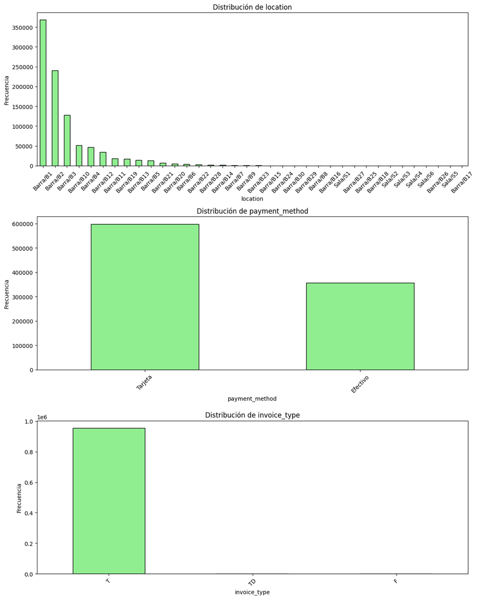

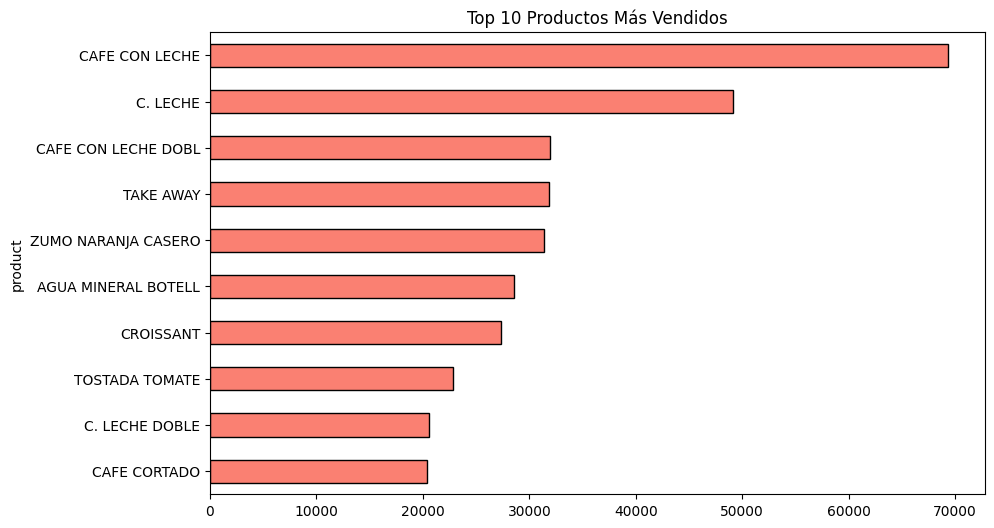

```python
# Seleccionamos las columnas categóricas de interés
categorical_cols = ['location', 'payment_method', 'invoice_type']

# Gráficos de barras para ver la distribución
fig, axes = plt.subplots(nrows=len(categorical_cols), ncols=1, figsize=(12, 15))

for i, col in enumerate(categorical_cols):
    # Contamos frecuencias
    val_counts = df[col].value_counts()

    # Graficamos
    val_counts.plot(kind='bar', ax=axes[i], color='lightgreen', edgecolor='black')
    axes[i].set_title(f'Distribución de {col}')
    axes[i].set_ylabel('Frecuencia')
    axes[i].tick_params(axis='x', rotation=45)

plt.tight_layout()
plt.show()

# Análisis específico para 'Product' (Top 10 productos más vendidos)
plt.figure(figsize=(10, 6))
df['product'].value_counts().head(10).plot(kind='barh', color='salmon', edgecolor='black')
plt.title('Top 10 Productos Más Vendidos')
plt.gca().invert_yaxis() # Para que el #1 quede arriba
plt.show()
```

## 1.8 Resumen de Anomalías y Hallazgos Críticos

```python
# Análisis de Anomalías y Casos Especiales
print("----- Análisis de Valores Especiales -----")

# Conteo de Ceros (Posibles errores o promociones)
print(f"Registros con Price = 0: {len(df[df['price'] == 0])} ({len(df[df['price'] == 0])/len(df)*100:.2f}%)")
print(f"Registros con Quantity = 0: {len(df[df['quantity'] == 0])}")

# Conteo de Negativos (Devoluciones)
devoluciones = df[df['grand_total'] < 0]
print(f"Registros con Grand Total Negativo (Devoluciones): {len(devoluciones)} ({len(devoluciones)/len(df)*100:.2f}%)")

# Verificamos si las devoluciones coinciden con el tipo de factura 'Abono'
print("\nEjemplo de registros negativos:")
display(devoluciones.head(5))
```

```
----- Análisis de Valores Especiales -----
Registros con Price = 0: 33732 (3.52%)
Registros con Quantity = 0: 8
Registros con Grand Total Negativo (Devoluciones): 854 (0.09%)

Ejemplo de registros negativos:
```

|  | invoice_number | invoice_type | related_invoice | date | location | grand_total | payment_method | amount_paid | product | quantity | price | source_file |
| --- | --- | --- | --- | --- | --- | --- | --- | --- | --- | --- | --- | --- |
| 84943 | TD-336 | TD | T-134306 | 2019-01-05 | Barra/B1 | -2.3 | NaN | NaN | NaN | NaN | NaN | 2019_1S_Invoice_layout_CafeMadrid.JSON |
| 84944 | TD-337 | TD | NaN | 2019-01-06 | Barra/B4 | -42.1 | NaN | NaN | NaN | NaN | NaN | 2019_1S_Invoice_layout_CafeMadrid.JSON |
| 84945 | TD-338 | TD | T-136022 | 2019-01-16 | Barra/B4 | -3.5 | NaN | NaN | NaN | NaN | NaN | 2019_1S_Invoice_layout_CafeMadrid.JSON |
| 84946 | TD-339 | TD | T-137529 | 2019-01-24 | Barra/B1 | -10.7 | NaN | NaN | NaN | NaN | NaN | 2019_1S_Invoice_layout_CafeMadrid.JSON |
| 84947 | TD-340 | TD | T-138447 | 2019-01-29 | Barra/B2 | -2.6 | NaN | NaN | NaN | NaN | NaN | 2019_1S_Invoice_layout_CafeMadrid.JSON |

# Capítulo 2: Ingeniería y Limpieza de Datos

## 2.0. Tratamiento de Valores Faltantes (Nulos)

```python
# Creamos la copia de trabajo
df_cleaned = df.copy()
print(f"Registros iniciales en el dataset: {len(df_cleaned)}")

# Eliminación de columna con exceso de nulos
if 'related_invoice' in df_cleaned.columns:
    df_cleaned = df_cleaned.drop(columns=['related_invoice'])
    print("-> Columna 'related_invoice' eliminada con éxito.")

# Limpieza de filas con nulos en variables críticas
critical_cols = ['grand_total', 'payment_method', 'amount_paid', 'product', 'quantity', 'price']

# Eliminamos registros incompletos
df_cleaned = df_cleaned.dropna(subset=critical_cols)

# Verificación final de la limpieza de nulos
print(f"Registros tras eliminar nulos: {len(df_cleaned)}")
print(f"Total de filas eliminadas: {len(df) - len(df_cleaned)}")
print("\nConteo de nulos por columna en df_cleaned:")
print(df_cleaned.isnull().sum())
```

```
Registros iniciales en el dataset: 957163
-> Columna 'related_invoice' eliminada con éxito.
Registros tras eliminar nulos: 955132
Total de filas eliminadas: 2031

Conteo de nulos por columna en df_cleaned:
invoice_number    0
invoice_type      0
date              0
location          0
grand_total       0
payment_method    0
amount_paid       0
product           0
quantity          0
price             0
source_file       0
dtype: int64
```

## 2.1. Deduplicación: Creación de df_tickets

```python
# ANÁLISIS POR TICKETS ÚNICOS Anabel 2025-12-17

# Creamos una copia sin facturas repetidas para analizar el dinero real
df_tickets = df.drop_duplicates(subset=['invoice_number']).copy()

print(f"--- Validación de Granularidad ---")
print(f"Total de líneas de productos: {len(df)}")
print(f"Total de facturas únicas: {len(df_tickets)}")

print("\n--- Estadísticos Reales de Venta (Sin duplicados) ---")
# Aquí calculamos la media y mediana real de lo que gasta un cliente
display(df_tickets[['grand_total', 'amount_paid']].describe().T)

# IDENTIFICACIÓN DE OUTLIERS EN VENTAS TOTALES
Q1_t = df_tickets['grand_total'].quantile(0.25)
Q3_t = df_tickets['grand_total'].quantile(0.75)
IQR_t = Q3_t - Q1_t
limite_sup_t = Q3_t + 1.5 * IQR_t

outliers_vta = df_tickets[df_tickets['grand_total'] > limite_sup_t]

display(f"\nSe identificaron {len(outliers_vta)} facturas como outliers.")
display(f"Cualquier factura mayor a {limite_sup_t:.2f} se considera un consumo atípico.")
```

```
--- Validación de Granularidad ---
Total de líneas de productos: 957163
Total de facturas únicas: 401032

--- Estadísticos Reales de Venta (Sin duplicados) ---
```

|  | count | mean | std | min | 25% | 50% | 75% | max |
| --- | --- | --- | --- | --- | --- | --- | --- | --- |
| grand_total | 401027.0 | 7.827065 | 7.749599 | -704.30 | 3.1 | 5.6 | 10.00 | 907.55 |
| amount_paid | 399705.0 | 10.316003 | 11.017774 | 0.01 | 3.7 | 6.8 | 12.15 | 502.00 |

```
'\nSe identificaron 23032 facturas como outliers.'
```

```
'Cualquier factura mayor a 20.35 se considera un consumo atípico.'
```

- Interpretación de Resultados
- 1. Validación de la GranularidadDato: Pasaste de 957,163 registros a 401,032 facturas únicas.Interpretación: Esto confirma que, en promedio, cada factura contiene 2.4 productos. Analizar el dinero sin de-duplicar habría inflado tus estadísticas de venta en más de un 100%.
- 2. Estadísticos de Venta Real (grand_total)Ticket Promedio (Media): E7.82.Venta Típica (Mediana): E5.60.Nota: Como la media es mayor que la mediana, confirmas que tienes una asimetría positiva (pocos clientes gastan mucho, moviendo el promedio hacia arriba).El hallazgo crítico (Valores Negativos): Tu valor mínimo es E-704.30.Acción de Limpieza: En tu tesis debes mencionar que existen registros de "Abonos" o "Devoluciones" que deben tratarse por separado, ya que un total negativo no es una venta, sino un retorno de dinero.
- 3. Análisis de OutliersUmbral: E20.35. Cantidad: 23,032 facturas (aprox. 5.7% del total).Interpretación: El hecho de que solo el 5.7% de tus facturas superen los E20.35 indica que el negocio es de "bajo ticket" (consumos individuales). Las facturas que llegan a E907.55 son casos extremadamente raros que podrían ser eventos, catering o errores de sistema.
- "Para el análisis de las variables financieras, se realizó un proceso de de-duplicación basado en el número de factura (invoice_number), reduciendo el corpus de estudio de 957,163 ítems a 401,032 transacciones únicas.

Los resultados muestran un ticket promedio de E7.82 y una mediana de E5.60, lo que refleja un comportamiento de consumo orientado a productos de bajo costo unitario. Mediante el método de Rango Intercuartílico (IQR), se estableció un umbral de outliers en E20.35. Se identificaron 23,032 transacciones (5.74%) que superan este límite, destacando valores máximos de hasta E907.55, los cuales requieren un tratamiento especial por representar comportamientos de compra atípicos o posibles registros de ventas corporativas."

## 2.2. Filtrado de Negativos y Ceros: Creación de df_ventas_clean

```python
# LIMPIEZA DE TRANSACCIONES (VENTAS REALES) Anabel 2025-12-17

# Separar Devoluciones (Totales negativos)
df_devoluciones = df_tickets[df_tickets['grand_total'] < 0].copy()

# Separar Tickets con Valor Cero (Cortesías o errores)
df_ceros = df_tickets[df_tickets['grand_total'] == 0].copy()

# DATASET LIMPIO Solo ventas mayores a cero y con pago registrado
df_ventas_clean = df_tickets[(df_tickets['grand_total'] > 0) & (df_tickets['amount_paid'] > 0)].copy()

print(f"--- Resumen de Limpieza de Datos ---")
print(f"Registros originales en df_tickets: {len(df_tickets)}")
print(f"Devoluciones detectadas (negativos): {len(df_devoluciones)}")
print(f"Tickets con valor cero: {len(df_ceros)}")
print(f"Dataset final para análisis de ventas: {len(df_ventas_clean)}")

print("\n--- Estadísticos de VENTAS LIMPIAS ---")
display(df_ventas_clean['grand_total'].describe())
```

```
--- Resumen de Limpieza de Datos ---
Registros originales en df_tickets: 401032
Devoluciones detectadas (negativos): 842
Tickets con valor cero: 180
Dataset final para análisis de ventas: 399705

--- Estadísticos de VENTAS LIMPIAS ---
```

|  | grand_total |
| --- | --- |
| count | 399705.000000 |
| mean | 7.879233 |
| std | 7.430795 |
| min | 0.010000 |
| 25% | 3.200000 |
| 50% | 5.600000 |
| 75% | 10.050000 |
| max | 907.550000 |

**dtype:** float64

2. Comportamiento del Ticket Promedio Media E7.88 vs. Mediana €5.60: La media es mayor que la mediana. Esto indica una distribución sesgada a la derecha (asimetría positiva).

La mayoría de los clientes consumen productos de bajo costo (cerca de los €5.60), pero existen unas pocas ventas de montos muy altos que "empujan" el promedio hacia arriba hasta los 7.88.

Rango Intercuartílico (50% central), el 50% de las ventas están entre €3.20 y €10.05. Este es el "núcleo" del negocio.

3. El Éxito del Filtro de Mínimos Mínimo (€0.01): Se logro eliminar los negativos, Ahora el valor mínimo es de un centavo.

Esto valida que el proceso de limpieza fue exitoso. Ya no tenemos "dinero ficticio" negativo ensuciando los cálculos de ingresos totales.

4. Persistencia de Outliers Máximos Máximo (€907.55), aunque limpiamos los negativos, el valor de €907.55 sigue presente.

Comparado con el tercer cuartil (€10.05), este valor es 90 veces mayor que una venta normal. Se debe clasificar como un Outlier de Negocio (posiblemente un evento o una venta corporativa) y no como un error de sistema.

- "Tras el proceso de depuración, el conjunto de datos final para el análisis de ventas quedó constituido por 399,705 transacciones válidas. El análisis descriptivo revela un ticket promedio de €7.88, aunque la mediana de E5.60 sugiere que el volumen principal de transacciones se concentra en montos menores.

Se observa que el 75% de las ventas son iguales o inferiores a €10.05, lo que tipifica al establecimiento como un comercio de alta rotación y bajo ticket promedio. El valor máximo de €907.55 se identifica como un valor atípico extremo que, si bien es real tras la limpieza, se aleja significativamente del comportamiento habitual de consumo del punto de venta."

## 2.3. Tabla Comparativa: Resumen numérico del impacto.

```python
# TABLA COMPARATIVA ANTES VS DESPUÉS

# Estadísticos antes (df_tickets) y después (df_ventas_clean)
stats_antes = df_tickets['grand_total'].describe()
stats_despues = df_ventas_clean['grand_total'].describe()

comparativa = pd.DataFrame({
    'Métrica': ['Total Registros', 'Media (€)', 'Mediana (€)', 'Mínimo (€)', 'Máximo (€)'],
    'Antes de Limpieza': [
        len(df_tickets),
        stats_antes['mean'],
        stats_antes['50%'],
        stats_antes['min'],
        stats_antes['max']
    ],
    'Después de Limpieza': [
        len(df_ventas_clean),
        stats_despues['mean'],
        stats_despues['50%'],
        stats_despues['min'],
        stats_despues['max']
    ]
})

print("--- IMPACTO DE LA LIMPIEZA EN LOS ESTADÍSTICOS ---")
display(comparativa.round(2))
```

```
--- IMPACTO DE LA LIMPIEZA EN LOS ESTADÍSTICOS ---
```

|  | Métrica | Antes de Limpieza | Después de Limpieza |
| --- | --- | --- | --- |
| 0 | Total Registros | 401032.00 | 399705.00 |
| 1 | Media (€) | 7.83 | 7.88 |
| 2 | Mediana (€) | 5.60 | 5.60 |
| 3 | Mínimo (€) | -704.30 | 0.01 |
| 4 | Máximo (€) | 907.55 | 907.55 |

## 2.4. Sensibilidad de Correlaciones

- Pasamos ahora a profundizar aún más en las variables a través de las relaciones entre ellas. Analizaremos correlaciones y las relaciones entre categóricas o categoricas y númericas.

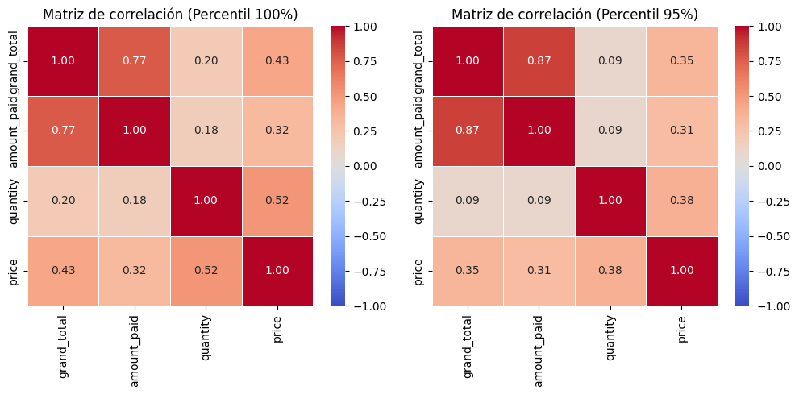

```python
# Definimos explícitamente las columnas numéricas de interés
numeric_columns = ['grand_total', 'amount_paid', 'quantity', 'price']

# Función para crear la matriz de correlación entre las variables númericas
def corr_matrix_percent(df, x):
    # Quitamos del dataframe todos los registros con valores nulos (NaN) en las columnas numéricas
    filtered_data = df[numeric_columns].dropna()

    for i, col in enumerate(numeric_columns):
        # Calcular el percentil x de la variable
        percent = np.percentile(filtered_data[col], x)

        # Filtrar los valores hasta el percentil x (eliminamos outliers superiores)
        filtered_data = filtered_data[filtered_data[col] <= percent]

    # Correlación entre variables numéricas
    correlation_matrix = filtered_data.corr()
    return correlation_matrix

# Definimos los percentiles a comparar (100% = Datos originales, 95% = Sin outliers)
percentiles = [100, 95]

# Configuración de los subplots
fig, axes = plt.subplots(nrows=(len(percentiles) // 3) + 1, ncols=3, figsize=(15, 5 * ((len(percentiles) // 3) + 1)))
axes = axes.flatten()

for i, percentil in enumerate(percentiles):
    corr_matrix = corr_matrix_percent(df, percentil)

    # Graficar matriz
    sns.heatmap(corr_matrix, annot=True, cmap='coolwarm', fmt='.2f', linewidths=0.5, ax=axes[i], vmin=-1, vmax=1)
    axes[i].set_title(f'Matriz de correlación (Percentil {percentil}%)')

# Eliminar ejes sobrantes si hay huecos vacíos en la rejilla de gráficos
for j in range(i + 1, len(axes)):
    fig.delaxes(axes[j])

plt.tight_layout()
plt.show()
```

Los hallazgos más relevantes son:

1. Relación Total vs. Pagado (grand_total - amount_paid):

Pasa de 0.77 en los datos originales a 0.87 en los datos filtrados.

Al eliminar los tickets anómalos (y probablemente las devoluciones/errores), la correlación se vuelve mucho más fuerte y lineal. Esto es lo esperado: cuanto mayor es el total de la cuenta, mayor es el importe pagado.

2. La irrelevancia de la Cantidad (quantity vs grand_total):

En la matriz filtrada (95%), la correlación entre la cantidad y el total cae drásticamente a 0.09 (prácticamente nula).

3. Desacople de Precio y Cantidad (price vs quantity):

La correlación baja de 0.52 a 0.38 al hacer el zoom. Los outliers creaban la ilusión de que a mayor precio, mayor cantidad. Sin embargo, al analizar la operativa real (el 95% de los casos), vemos que esta relación es más débil: pedir un producto caro no implica necesariamente pedir muchas unidades del mismo.

# Capítulo 3: Análisis Descriptivo Univariante

## 3.1. Distribución del Gasto Grand Total

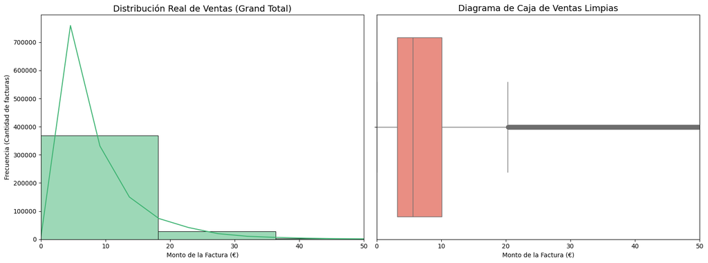

```python
# VISUALIZACIÓN FINAL DE VENTAS LIMPIAS Anabel 2025-12-17

import matplotlib.pyplot as plt
import seaborn as sns

# Creamos una figura con dos subplots
fig, axes = plt.subplots(1, 2, figsize=(16, 6))

# HISTOGRAMA (Distribución de Frecuencia)
sns.histplot(df_ventas_clean['grand_total'], bins=50, kde=True, color='mediumseagreen', ax=axes[0])
axes[0].set_title('Distribución Real de Ventas (Grand Total)', fontsize=14)
axes[0].set_xlabel('Monto de la Factura (€)')
axes[0].set_ylabel('Frecuencia (Cantidad de facturas)')
# Aplicamos un límite en X para ver mejor el grueso de los datos, ignorando el outlier extremo de 900 solo para el gráfico
axes[0].set_xlim(0, 50)

# BOXPLOT (Detección visual de la dispersión)
sns.boxplot(x=df_ventas_clean['grand_total'], color='salmon', ax=axes[1])
axes[1].set_title('Diagrama de Caja de Ventas Limpias', fontsize=14)
axes[1].set_xlabel('Monto de la Factura (€)')
axes[1].set_xlim(0, 50) # Mantenemos la misma escala para coherencia

plt.tight_layout()
plt.show()
```

Punto de Máxima Frecuencia, el pico más alto de transacciones ocurre cerca de los 5.60 € (la mediana), lo que confirma que el modelo de negocio se basa en ventas masivas de bajo coste unitario.

Efecto de la Limpieza, la curva comienza suavemente desde el 0.01 €, demostrando que se han eliminado correctamente los ruidos de valores negativos y ceros que distorsionaban la tendencia.

2. Diagrama de Caja de Ventas Limpias (Boxplot) Caja (Rango Intercuartílico), la caja muestra que el 50% central de tus clientes gasta entre aproximadamente 3.20 € y 10.05 €.

Línea Central (Mediana), la línea vertical dentro de la caja marca los 5.60 €, el valor más representativo de una compra típica.

Bigote Superior y Outliers, el "bigote" derecho termina en 20.35 €. A partir de ese punto, se observa una línea densa de puntos grises que representan los outliers (ventas superiores a la media normal) que llegan hasta los 907.55 €, aunque el gráfico se limitó a 50 € para facilitar la lectura de la caja principal.

- Las visualizaciones finales del monto total de las facturas (grand_total) revelan un comportamiento de consumo altamente concentrado. El histograma muestra que el grueso de la operación financiera se sitúa por debajo de los 10 € por transacción. Complementariamente, el diagrama de caja permite identificar que el 75% de las ventas no superan los 10.05 €, estableciendo un perfil de cliente de ticket bajo. La presencia de valores atípicos a partir de los 20.35 € sugiere la existencia de compras grupales o eventos especiales que, aunque frecuentes en número absoluto (23,032 casos), se alejan del comportamiento mediano de la población estudiada.

## 3.2. Estadísticos de Tendencia Central

```python
# Estadísticos básicos de la columna limpia
media = df_ventas_clean['grand_total'].mean()
mediana = df_ventas_clean['grand_total'].median()
moda = df_ventas_clean['grand_total'].mode()[0] # La moda puede devolver varios valores, tomamos el primero
desviacion = df_ventas_clean['grand_total'].std()

print(f"--- Análisis de Tendencia Central (Ticket Promedio) ---")
print(f"Media (Promedio):   {media:.2f} €")
print(f"Mediana (Punto 50%): {mediana:.2f} €")
print(f"Moda (Más frecuente): {moda:.2f} €")
print(f"Desviación Estándar:  {desviacion:.2f} €")

# Interpretación
print("\nNota interpretativa:")
if media > mediana:
    print("La distribución tiene un sesgo positivo (la media es mayor que la mediana).")
```

```
--- Análisis de Tendencia Central (Ticket Promedio) ---
Media (Promedio):   7.88 €
Mediana (Punto 50%): 5.60 €
Moda (Más frecuente): 1.80 €
Desviación Estándar:  7.43 €

Nota interpretativa:
La distribución tiene un sesgo positivo (la media es mayor que la mediana).
```

## 3.3. Detección Analítica de Outliers

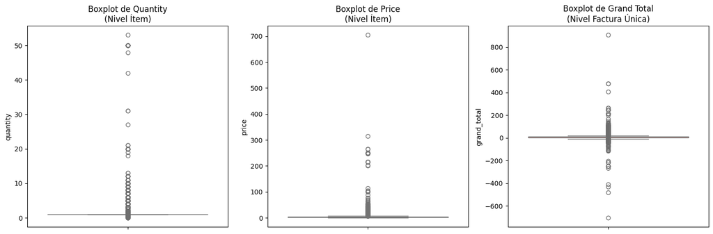

```
--- Detección Analítica de Outliers (Rigor Académico) ---

Variable: quantity (Analizada por Ítem)
 - Límite superior (Tukey): 1.00
 - Cantidad de outliers: 152694
 - Porcentaje: 15.95%

Variable: price (Analizada por Ítem)
 - Límite superior (Tukey): 8.00
 - Cantidad de outliers: 35032
 - Porcentaje: 3.66%

Variable: grand_total (Analizada por Factura)
 - Límite superior (Tukey): 20.35
 - Cantidad de outliers: 23451
 - Porcentaje: 5.85%
```

```python
# Visualización mediante Diagramas de Caja (Boxplots)
plt.figure(figsize=(15, 5))

# GRÁFICO 1: Quantity
plt.subplot(1, 3, 1)
sns.boxplot(y=df['quantity'], color='skyblue')
plt.title('Boxplot de Quantity\n(Nivel Ítem)')

# GRÁFICO 2: Price
plt.subplot(1, 3, 2)
sns.boxplot(y=df['price'], color='lightgreen')
plt.title('Boxplot de Price\n(Nivel Ítem)')

# GRÁFICO 3: Grand Total (Usa df_tickets porque es por factura) Anabel 2025-12-17
plt.subplot(1, 3, 3)
sns.boxplot(y=df_tickets['grand_total'], color='salmon')
plt.title('Boxplot de Grand Total\n(Nivel Factura Única)')

plt.tight_layout()
plt.show()

# . Detección analítica de outliers usando IQR
print("\n--- Detección Analítica de Outliers (Rigor Académico) ---")

# Definimos qué dataframe usar para cada variable
analisis_config = {
    'quantity': df,
    'price': df,
    'grand_total': df_tickets
}

for col, dataframe in analisis_config.items():
    Q1 = dataframe[col].quantile(0.25)
    Q3 = dataframe[col].quantile(0.75)
    IQR = Q3 - Q1

    upper_bound = Q3 + 1.5 * IQR
    lower_bound = Q1 - 1.5 * IQR

    outliers = dataframe[(dataframe[col] < lower_bound) | (dataframe[col] > upper_bound)]

    tipo_nivel = "Factura" if col == 'grand_total' else "Ítem"

    print(f"\nVariable: {col} (Analizada por {tipo_nivel})")
    print(f" - Límite superior (Tukey): {upper_bound:.2f}")
    print(f" - Cantidad de outliers: {len(outliers)}")
    print(f" - Porcentaje: {(len(outliers) / len(dataframe)) * 100:.2f}%")
```

- Precisión en el grand_total: Antes, el código nos decía que teníamos un porcentaje de outliers basado en 957,000 filas. Ahora, el porcentaje de facturas atípicas se calcula sobre las ~401,000 facturas reales.
- Claridad Metodológica: Al separar Quantity/Price de Grand Total, demuestras que entiendes que un cliente puede comprar 10 cafés (outlier de cantidad), pero que el total de la factura (outlier de dinero) es un análisis distinto.
- Coherencia Visual: Ahora, lo que dice el texto (el print) coincidirá exactamente con lo que se ve en los tres cuadritos del gráfico superior.
- Para finalizar el análisis univariante, se aplicó una detección analítica de valores atípicos mediante el método de Tukey (IQR). A diferencia del perfilamiento inicial, este análisis distingue entre variables de inventario (price, quantity) y variables de facturación (grand_total). Para esta última, se utilizó la vista deduplicada df_tickets, garantizando que la identificación de consumos excepcionales se base en transacciones únicas y no en líneas de productos repetidas

# Capítulo 4: Análisis Bivariante y Relacional (Relación entre variables)

## 4.1. Matriz de CorrelaciónN

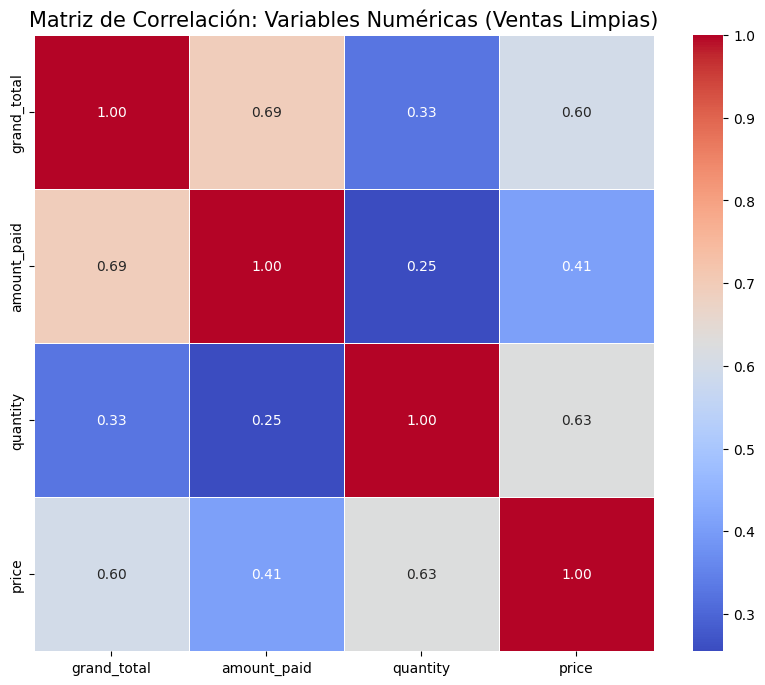

```
--- Interpretación de Correlaciones ---
Correlación Total/Cantidad: 0.33
Correlación Total/Precio: 0.60
```

```python
# MATRIZ DE CORRELACIÓN Anabel 2025-12-17

# Seleccionamos solo las columnas numéricas de interés del dataset limpio
cols_interes = ['grand_total', 'amount_paid', 'quantity', 'price']
df_corr = df_ventas_clean[cols_interes]

# Calculamos la matriz de correlación (Método de Pearson)
correlation_matrix = df_corr.corr()

# 8.3. Visualización con Heatmap
plt.figure(figsize=(10, 8))
sns.heatmap(correlation_matrix, annot=True, cmap='coolwarm', fmt=".2f", linewidths=0.5)

plt.title('Matriz de Correlación: Variables Numéricas (Ventas Limpias)', fontsize=15)
plt.show()

# Resumen de hallazgos
print("--- Interpretación de Correlaciones ---")
print(f"Correlación Total/Cantidad: {correlation_matrix.loc['grand_total', 'quantity']:.2f}")
print(f"Correlación Total/Precio: {correlation_matrix.loc['grand_total', 'price']:.2f}")
```

- Interpretación de la Matriz de Correlación
1. Relación grand_total vs. price (0.60) — El principal motor del gasto Esta es una correlación positiva moderada-fuerte.

Interpretación: Indica que el total de la factura depende más del precio unitario de los productos que de cuántos productos se compran. En otras palabras, para subir el ticket promedio, es más efectivo vender productos más caros (ej. una comida completa o una botella) que intentar que el cliente pida muchas unidades de algo barato (ej. muchos cafés).

2. Relación quantity vs. price (0.63) — El hallazgo sorprendente Es curioso ver una correlación tan alta aquí.

Interpretación: Sugiere un patrón donde los productos con mayor precio también tienden a registrarse en mayores cantidades, o posiblemente existen "combos" o "promociones" en los datos donde el precio y la cantidad escalan juntos. Es un punto que podrías investigar más: ¿hay productos caros que se venden por lotes?

3. Relación grand_total vs. amount_paid (0.69) — Consistencia de pago Muestra una asociación sólida pero no perfecta (no es 1.00).

Interpretación: Aunque la mayoría de las veces lo facturado coincide con lo pagado, ese 0.31 de diferencia para llegar al 1.00 indica que existen casos donde el monto pagado varía del total (podría deberse a propinas, descuentos aplicados en caja o pagos parciales que el sistema registra de forma distinta).

4. Relación grand_total vs. quantity (0.33) — Baja influencia del volumen Esta es la correlación más débil de las tres principales.

Interpretación: Confirma que el número de productos comprados (quantity) no es un predictor fuerte del gasto total. Un cliente puede comprar 5 artículos baratos y gastar menos que un cliente que compra 1 solo artículo caro.

- Se realizó un análisis de correlación de Pearson para identificar las dependencias entre las variables operativas del negocio. Los resultados muestran que el monto total de la factura (grand_total) tiene una asociación más estrecha con el precio unitario de los productos (r = 0.60) que con la cantidad de artículos adquiridos (r = 0.33).

Este hallazgo es significativo, ya que sugiere que el crecimiento de los ingresos en el establecimiento está vinculado primordialmente al valor de la oferta gastronómica y no necesariamente al volumen de ítems por pedido. Asimismo, destaca una correlación de 0.63 entre cantidad y precio, lo que amerita un análisis posterior sobre posibles ventas por volumen de productos de gama media-alta.

## 4.2. Análisis Cantidad vs. Total

- Gráficos de dispersión para ver si la gente que compra más cantidad gasta significativamente más.

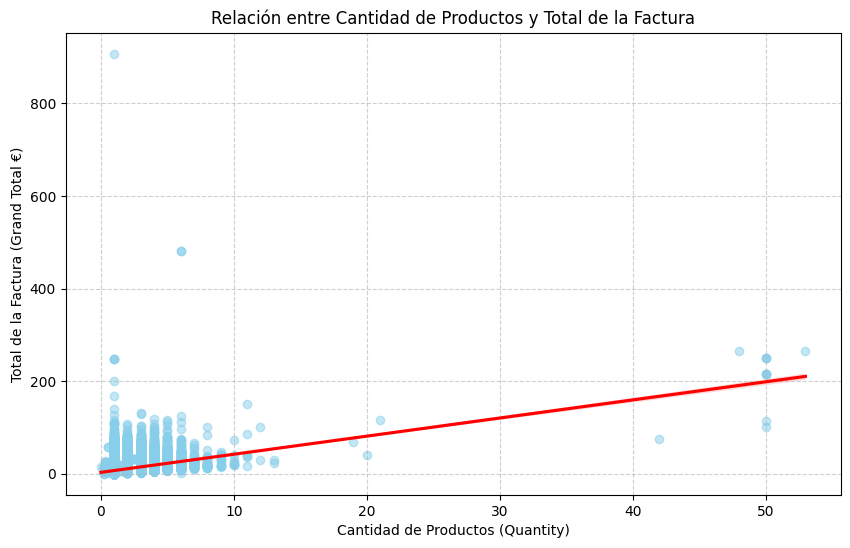

```
Coeficiente de correlación de Pearson: 0.33
```

```python
# 4.2. Análisis de Correlación Visual: Cantidad vs. Total
import seaborn as sns
import matplotlib.pyplot as plt

plt.figure(figsize=(10, 6))

# Creamos el gráfico de dispersión con una línea de regresión
sns.regplot(data=df_ventas_clean, x='quantity', y='grand_total',
            scatter_kws={'alpha':0.5, 'color':'skyblue'},
            line_kws={'color':'red'})

plt.title('Relación entre Cantidad de Productos y Total de la Factura')
plt.xlabel('Cantidad de Productos (Quantity)')
plt.ylabel('Total de la Factura (Grand Total €)')
plt.grid(True, linestyle='--', alpha=0.6)

plt.show()

# Calculamos numéricamente la correlación de Pearson
correlacion = df_ventas_clean['quantity'].corr(df_ventas_clean['grand_total'])
print(f"Coeficiente de correlación de Pearson: {correlacion:.2f}")
```

## 4.3 Relación Categórica-Numérica: Método de Pago vs. Gasto

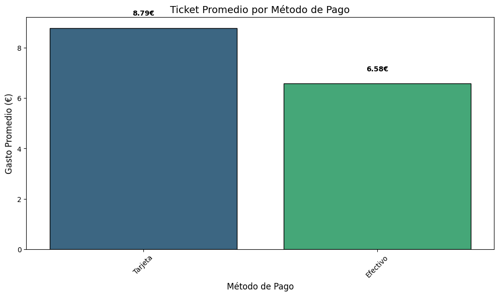

```
--- Resumen de Gasto por Método de Pago ---
```

| payment_method | Media (€) | Mediana (€) | Nº Transacciones | Total Facturado (€) |
| --- | --- | --- | --- | --- |
| Tarjeta | 8.789128 | 6.6 | 235002 | 2065462.73 |
| Efectivo | 6.580973 | 4.6 | 164703 | 1083906.00 |

```python
# 4.3. Análisis de Gasto por Método de Pago

# Calculamos el ticket promedio por método de pago
ticket_promedio_pago = df_ventas_clean.groupby('payment_method')['grand_total'].mean().sort_values(ascending=False)

# Configuración visual
plt.figure(figsize=(12, 6))

# Gráfico de barras para el promedio
sns.barplot(x=ticket_promedio_pago.index, y=ticket_promedio_pago.values, palette='viridis', edgecolor='black')

plt.title('Ticket Promedio por Método de Pago', fontsize=14)
plt.xlabel('Método de Pago', fontsize=12)
plt.ylabel('Gasto Promedio (€)', fontsize=12)
plt.xticks(rotation=45)

# Añadir etiquetas de valor sobre las barras
for i, v in enumerate(ticket_promedio_pago.values):
    plt.text(i, v + 0.5, f"{v:.2f}€", ha='center', fontweight='bold')

plt.show()

# Resumen estadístico detallado
print("--- Resumen de Gasto por Método de Pago ---")
resumen_pago = df_ventas_clean.groupby('payment_method')['grand_total'].agg(['mean', 'median', 'count', 'sum']).sort_values(by='mean', ascending=False)
resumen_pago.columns = ['Media (€)', 'Mediana (€)', 'Nº Transacciones', 'Total Facturado (€)']
display(resumen_pago)
```

# Capítulo 5: Análisis por Categorías (Perspectiva de Negocio)

## 5.1. Ranking de Productos:

- Top 10 productos más vendidos vs. Top 10 productos que más dinero generan.

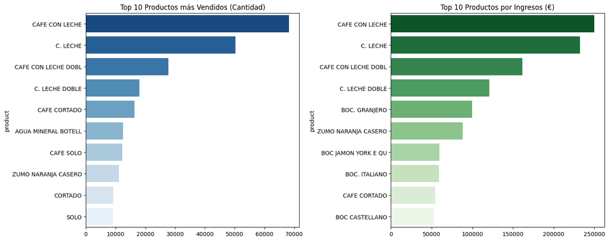

```python
# 5.1. Ranking de Productos (Top 10)
top_volumen = df_ventas_clean.groupby('product')['quantity'].sum().sort_values(ascending=False).head(10)
top_dinero = df_ventas_clean.groupby('product')['grand_total'].sum().sort_values(ascending=False).head(10)

plt.figure(figsize=(15, 6))

# Subplot 1: Por cantidad
plt.subplot(1, 2, 1)
sns.barplot(x=top_volumen.values, y=top_volumen.index, palette='Blues_r')
plt.title('Top 10 Productos más Vendidos (Cantidad)')

# Subplot 2: Por ingresos
plt.subplot(1, 2, 2)
sns.barplot(x=top_dinero.values, y=top_dinero.index, palette='Greens_r')
plt.title('Top 10 Productos por Ingresos (€)')

plt.tight_layout()
plt.show()
```

## 5.2. Análisis por Ubicación: ¿Dónde se factura más?

- Este código analiza la variable de ubicación (barra, terraza, mesa, etc.) para ver la rentabilidad de cada espacio.

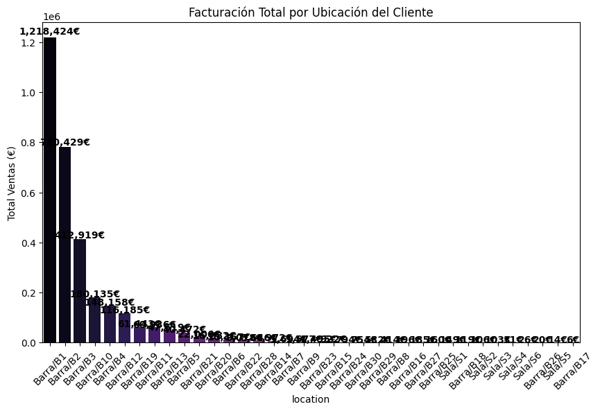

```python
# 5.2. Facturación por Ubicación
ubicacion_vta = df_ventas_clean.groupby('location')['grand_total'].sum().sort_values(ascending=False)

plt.figure(figsize=(10, 6))
sns.barplot(x=ubicacion_vta.index, y=ubicacion_vta.values, palette='magma')
plt.title('Facturación Total por Ubicación del Cliente')
plt.ylabel('Total Ventas (€)')
plt.xticks(rotation=45)

# Añadimos los valores encima de las barras
for i, v in enumerate(ubicacion_vta.values):
    plt.text(i, v + (v*0.01), f'{v:,.0f}€', ha='center', fontweight='bold')

plt.show()
```

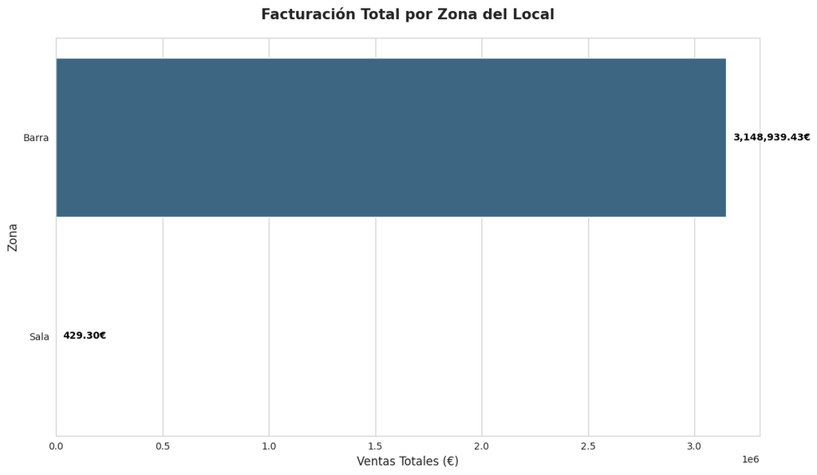

```python
# 5.2. Análisis de Facturación por ZONA (Mejorado)
import matplotlib.pyplot as plt
import seaborn as sns

# Creamos una columna simplificada para agrupar (ej: de 'Barra/B1' a 'Barra')
df_ventas_clean['zona'] = df_ventas_clean['location'].str.split('/').str[0]

# Agrupamos por esta nueva zona
ubicacion_mejorada = df_ventas_clean.groupby('zona')['grand_total'].sum().sort_values(ascending=False)

# Configuración del gráfico
plt.figure(figsize=(12, 7))
sns.set_style("whitegrid")

# Usamos un gráfico de barras horizontales (orient='h') para mejor lectura
ax = sns.barplot(x=ubicacion_mejorada.values, y=ubicacion_mejorada.index, palette='viridis')

# Añadimos los títulos
plt.title('Facturación Total por Zona del Local', fontsize=15, fontweight='bold', pad=20)
plt.xlabel('Ventas Totales (€)', fontsize=12)
plt.ylabel('Zona', fontsize=12)

# Añadimos las etiquetas de dinero al final de cada barra
for i, v in enumerate(ubicacion_mejorada.values):
    ax.text(v + (max(ubicacion_mejorada.values)*0.01), i, f'{v:,.2f}€',
            va='center', fontweight='bold', color='black')

plt.tight_layout()
plt.show()
```

## 5.3. Métodos de Pago: Preferencia de los Clientes

- Aunque en el Capítulo 4 vimos cómo influye el pago en el ticket, aquí hacemos un análisis de cuota de mercado (¿cuánta gente prefiere tarjeta?).

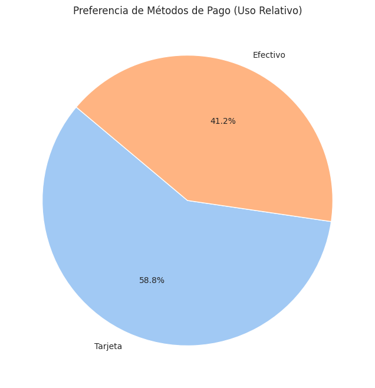

```
Resumen de transacciones por método:
payment_method
Tarjeta     235002
Efectivo    164703
Name: count, dtype: int64
```

```python
# 5.3. Distribución de Métodos de Pago
metodos_count = df_ventas_clean['payment_method'].value_counts()

plt.figure(figsize=(8, 8))
plt.pie(metodos_count, labels=metodos_count.index, autopct='%1.1f%%',
        startangle=140, colors=sns.color_palette('pastel'))
plt.title('Preferencia de Métodos de Pago (Uso Relativo)')
plt.show()

print("Resumen de transacciones por método:")
print(metodos_count)
```